# HW1

Seth Russell

3/27/2018

Note to self: Use http://www.stat.cmu.edu/~cshalizi/rmarkdown/ to figure out math symbols!

## 2. Simulation, linear regression, variance explained, predictions and predictive accuracy

In this exercise you’ll create some simulated data from a linear model of a continuous outcome and will fit simple regression models to them. Make sure to set a seed prior to starting part (a) to ensure consistent results. Use base R and the rms package.

### (a) Using the rnorm() function, create a vector, x, containing 100 observations drawn from a N(0, 1) distribution. This represents a feature, X.

```r
set.seed(1984)
x <- rnorm(100, 0, 1)
```

### (b) Using the rnorm()function, create a vector, eps, containing 100 observations drawn from a N(0, 0.25) distribution i.e. a normal distribution with mean zero and variance 0.25.

```r
set.seed(1776)
eps <- rnorm(100, 0, 0.25)
```

### (c) Using x and eps, generate a vector y according to the model

Y = -1 + 0.5X + $\epsilon$

```r
y <- -1 + 0.5 * x + eps
```

### (d) Create a scatterplot displaying the relationship between x and y. Comment on what you observe.

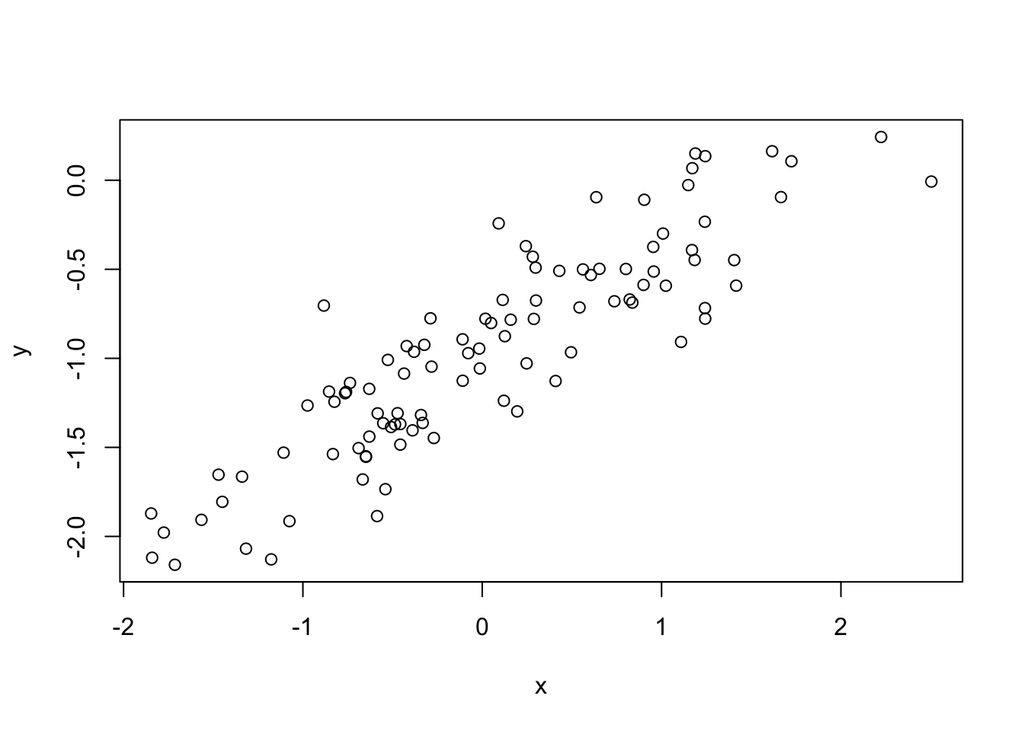

```r
plot(x, y)
```

Result is what appears to be an approximately linear relationship between x and y

### (e) Fit a least squares linear model to predict y using x. Comment on the model obtained. How do $\hat{\beta_0}$ and $\hat{\beta_1}$ compare to $\beta_0$ and $\beta_1$ ?

```r
g <- rms::ols(y ~ x)
g
```

```
## Linear Regression Model
##
##  rms::ols(formula = y ~ x)
##
##                 Model Likelihood     Discrimination
##                    Ratio Test           Indexes
##  Obs     100    LR chi2    155.61    R2       0.789
##  sigma0.2725    d.f.            1    R2 adj   0.787
##  d.f.     98    Pr(> chi2) 0.0000    g        0.599
##
##  Residuals
##
##       Min       1Q   Median       3Q      Max
##  -0.58362 -0.17994 -0.01112  0.18878  0.76363
##
##
##            Coef    S.E.   t      Pr(>|t|)
##  Intercept -0.9757 0.0273 -35.78 <0.0001
##  x          0.5570 0.0291  19.15 <0.0001
##
```

```r
anova(g)
```

```
##                 Analysis of Variance          Response: y
##
##  Factor     d.f. Partial SS MS          F      P
##  x           1   27.220947  27.22094654 366.54 <.0001
##  REGRESSION  1   27.220947  27.22094654 366.54 <.0001
##  ERROR      98    7.277929   0.07426458
```

```r
dd <- datadist(x, y)
options(datadist="dd")
summary(g)
```

```
##              Effects              Response : y
##
##  Factor Low      High    Diff. Effect  S.E.     Lower 0.95 Upper 0.95
##  x      -0.62964 0.80631 1.436 0.79983 0.041777 0.71692    0.88273
```

```r
AIC(g)
```

```
##     d.f.
## 27.75532
```

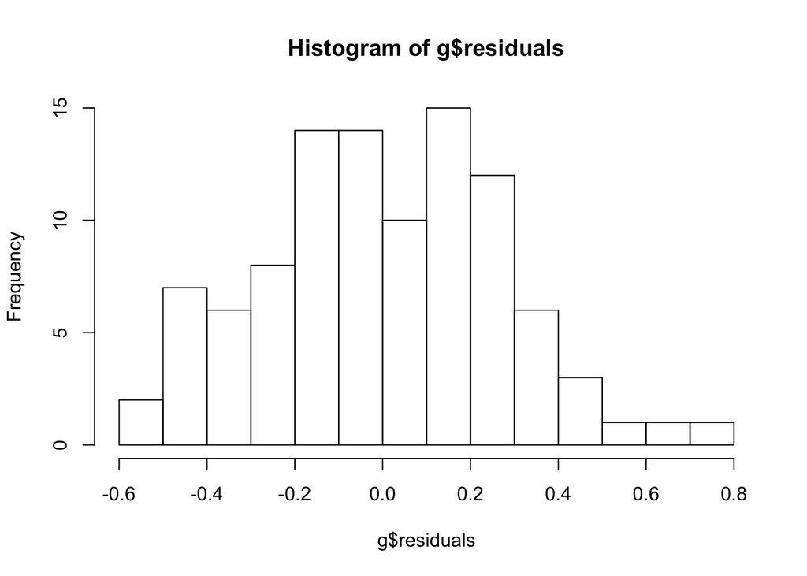

```r
hist(g$residuals, breaks=14)
```

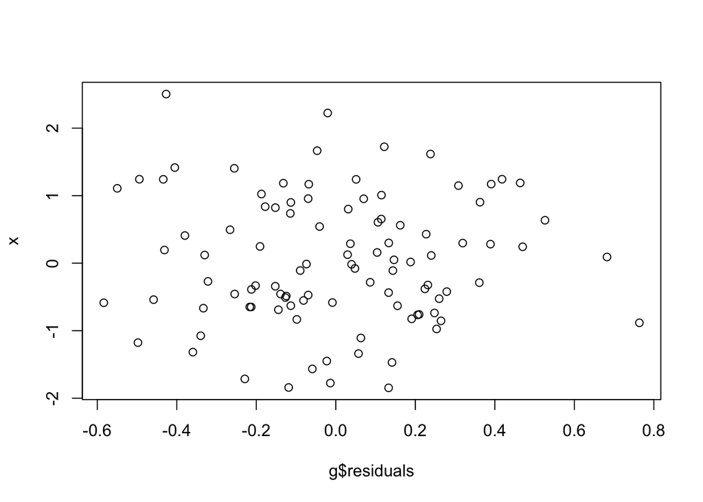

```r
plot(g$residuals, x)
```

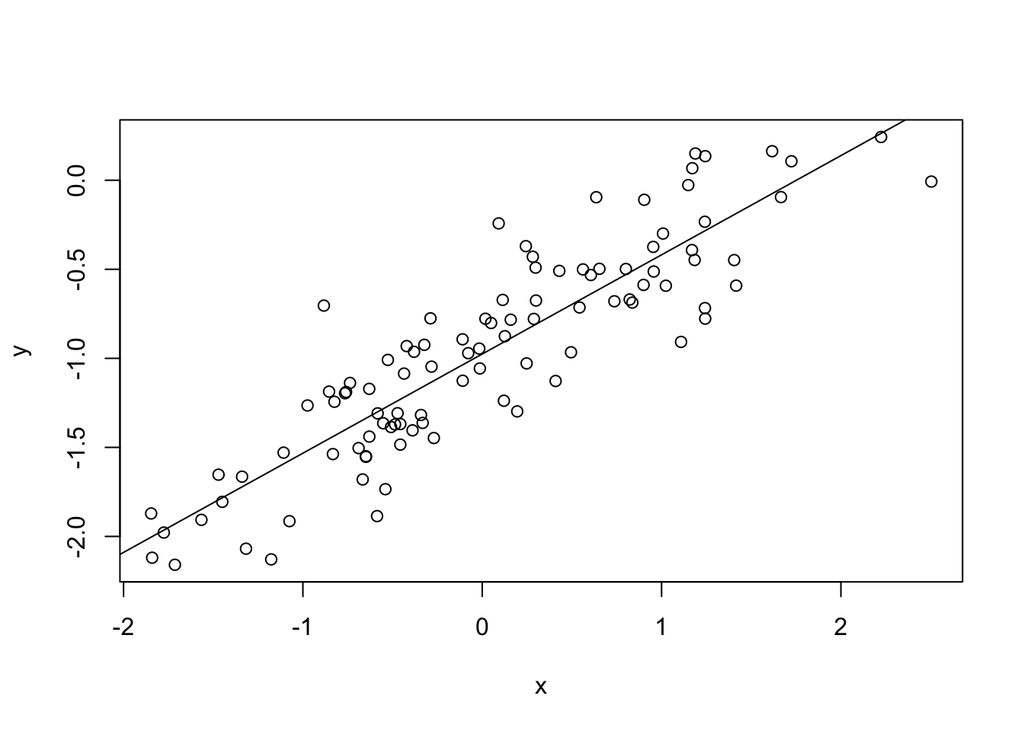

```r
plot(x, y)
abline(g)
```

Line generated by least squares method goes through center of random data that has a linear shape. By visual inspection, only in 1 case does the linear function exactly match actual data, but some are close to the linear function.

As shown via the residual plot, the values are off from the regression line by apparently a random amount (doesn’t seem to have a visual pattern) ranging from -0.6 to 0.8.

### (f) Now fit a polynomial regression model that predicts y using x and x2. Is there evidence that the quadratic term improves the model fit? Explain your answer.

```r
x2 = x^2
p <- rms::ols(y ~ x + x2)
p
```

```
## Linear Regression Model
##
##  rms::ols(formula = y ~ x + x2)
##
##                 Model Likelihood     Discrimination
##                    Ratio Test           Indexes
##  Obs     100    LR chi2    158.02    R2       0.794
##  sigma0.2706    d.f.            2    R2 adj   0.790
##  d.f.     97    Pr(> chi2) 0.0000    g        0.602
##
##  Residuals
##
##      Min      1Q  Median      3Q     Max
##  -0.5991 -0.1812  0.0140  0.1976  0.7676
##
##
##            Coef    S.E.   t      Pr(>|t|)
##  Intercept -0.9419 0.0349 -27.03 <0.0001
##  x          0.5655 0.0294  19.23 <0.0001
##  x2        -0.0388 0.0252  -1.54 0.1270
##
```

```r
anova(p)
```

```
##                 Analysis of Variance          Response: y
##
##  Factor     d.f. Partial SS MS         F      P
##  x           1   27.0724905 27.0724905 369.63 <.0001
##  x2          1    0.1735035  0.1735035   2.37 0.127
##  REGRESSION  2   27.3944500 13.6972250 187.01 <.0001
##  ERROR      97    7.1044253  0.0732415
```

```r
dd <- datadist(x, x2, y)
options(datadist="dd")
summary(p)
```

```
##              Effects              Response : y
##
##  Factor Low      High    Diff.  Effect   S.E.     Lower 0.95 Upper 0.95
##  x      -0.62964 0.80631 1.4360  0.81200 0.042235  0.72817   0.895820
##  x2      0.13760 1.33190 1.1943 -0.04628 0.030069 -0.10596   0.013398
```

```r
AIC(p)
```

```
##     d.f.
## 27.34248
```

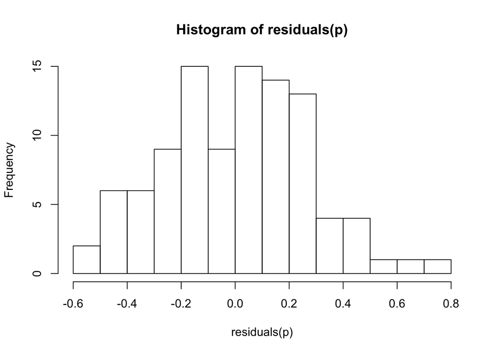

```r
#plot(p$residuals, x)
hist(residuals(p), breaks=14)
```

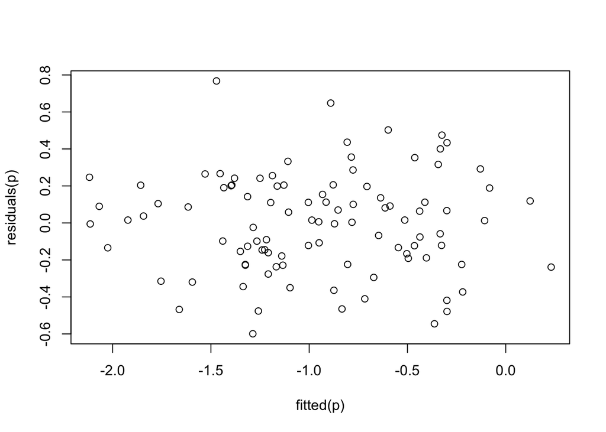

```r
plot(fitted(p),residuals(p))
```

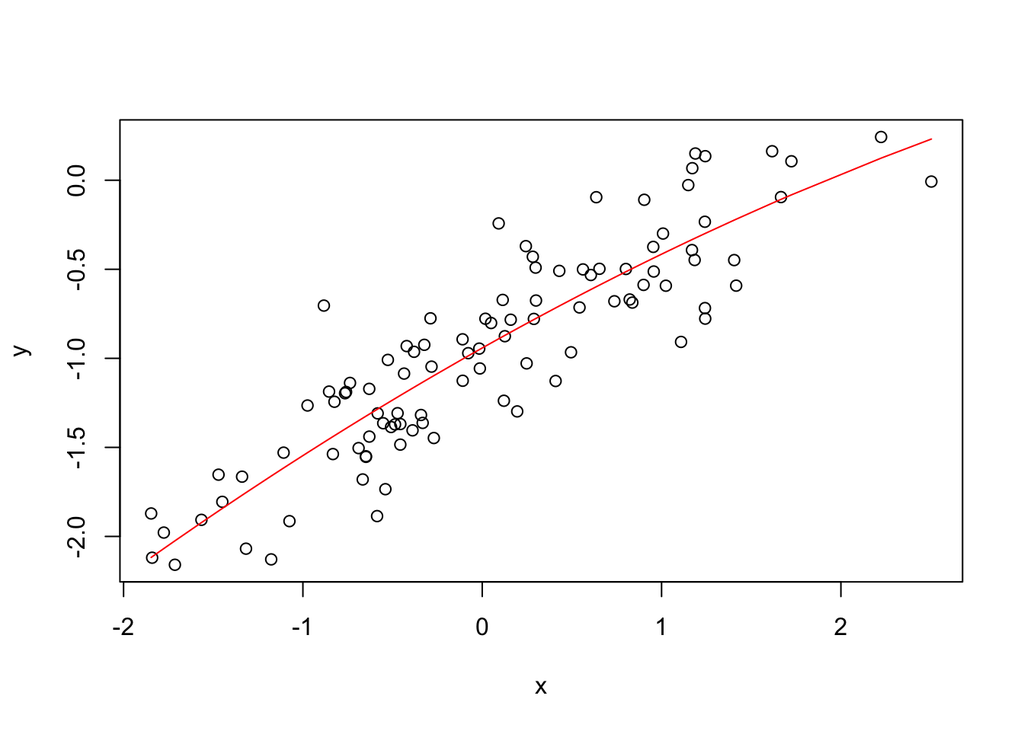

```r
plot(x, y)
y_pred <- predict(p, data.frame(x, x2))
lines(sort(x), y_pred[order(x)], col = "red")
```

### (g) Repeat (a)–(f) after modifying the data generation process in such a way that there is less noise in the data. Describe your results.

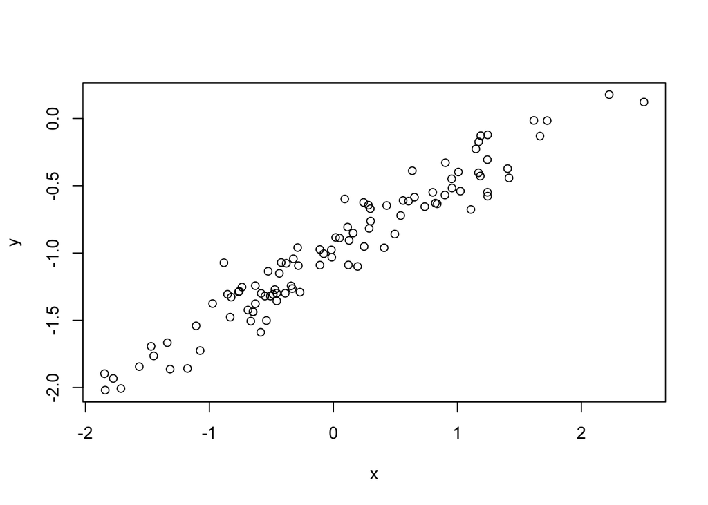

```r
set.seed(1984)
x <- rnorm(100, 0, 1)
set.seed(1776)
eps <- rnorm(100, 0, 0.125)
y <- -1 + 0.5 * x + eps
plot(x, y)
```

```r
g <- rms::ols(y ~ x)
g
```

```
## Linear Regression Model
##
##  rms::ols(formula = y ~ x)
##
##                 Model Likelihood     Discrimination
##                    Ratio Test           Indexes
##  Obs     100    LR chi2    267.20    R2       0.931
##  sigma0.1363    d.f.            1    R2 adj   0.930
##  d.f.     98    Pr(> chi2) 0.0000    g        0.568
##
##  Residuals
##
##        Min        1Q    Median        3Q       Max
##  -0.291808 -0.089971 -0.005558  0.094390  0.381813
##
##
##            Coef    S.E.   t      Pr(>|t|)
##  Intercept -0.9878 0.0136 -72.46 <0.0001
##  x          0.5285 0.0145  36.33 <0.0001
##
```

```r
anova(g)
```

```
##                 Analysis of Variance          Response: y
##
##  Factor     d.f. Partial SS MS          F       P
##  x           1   24.506556  24.50655555 1319.96 <.0001
##  REGRESSION  1   24.506556  24.50655555 1319.96 <.0001
##  ERROR      98    1.819482   0.01856614
```

```r
dd <- datadist(x, y)
options(datadist="dd")
summary(g)
```

```
##              Effects              Response : y
##
##  Factor Low      High    Diff. Effect S.E.     Lower 0.95 Upper 0.95
##  x      -0.62964 0.80631 1.436 0.7589 0.020888 0.71745    0.80036
```

```r
print('AIC:')
```

```
## [1] "AIC:"
```

```r
AIC(g)
```

```
##      d.f.
## -110.8741
```

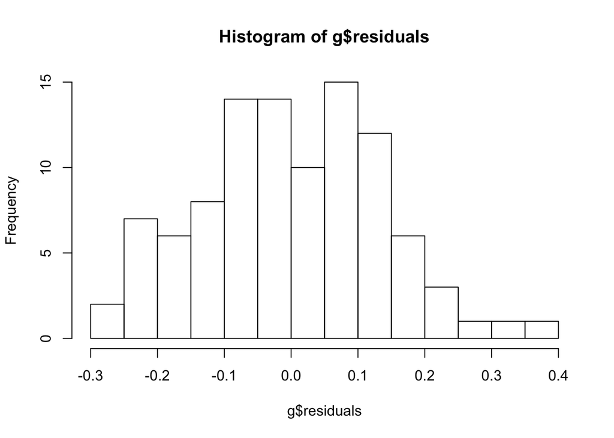

```r
hist(g$residuals, breaks=14)
```

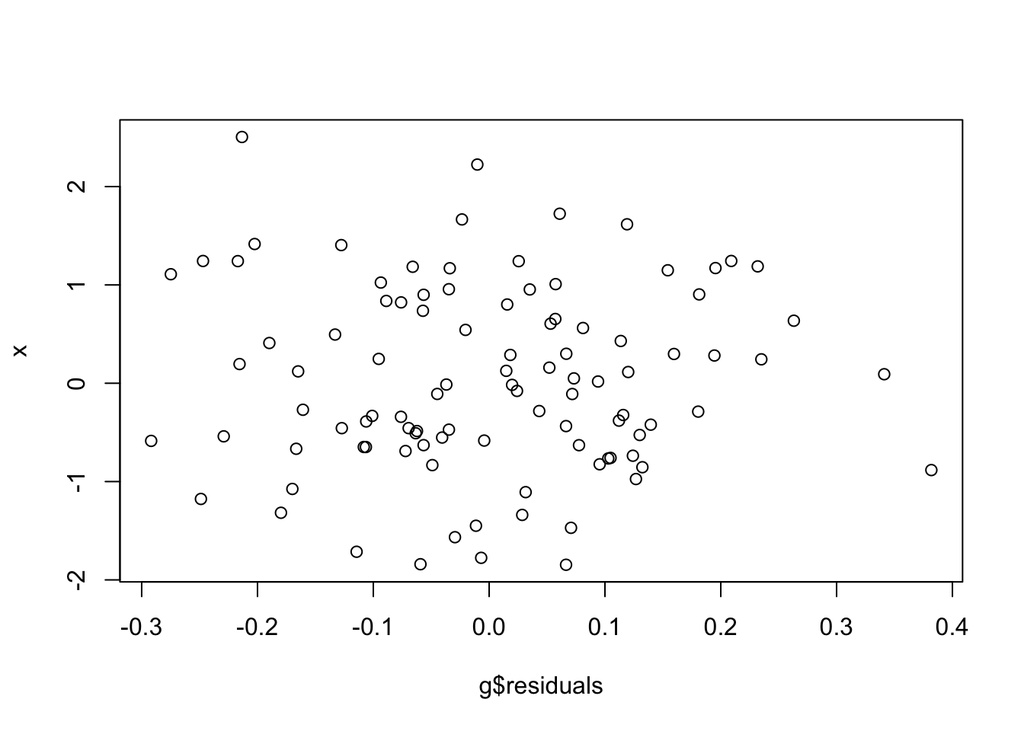

```r
plot(g$residuals, x)
```

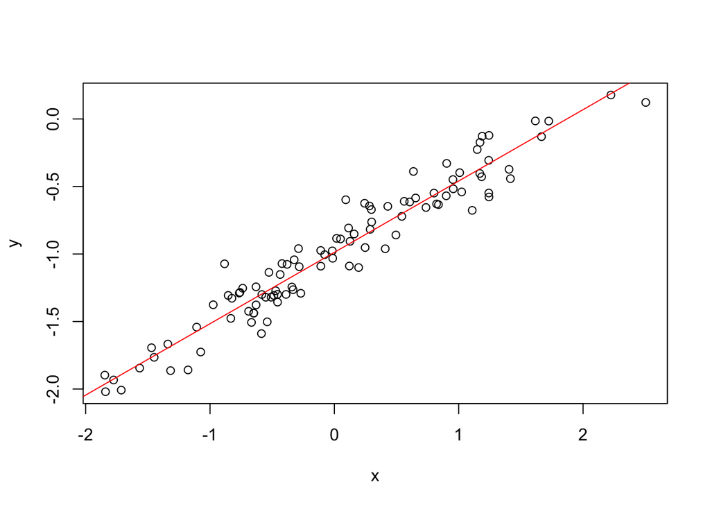

```r
plot(x, y)
abline(g, col='red')
```

```r
x2 = x^2
p <- rms::ols(y ~ x + x2)
p
```

```
## Linear Regression Model
##
##  rms::ols(formula = y ~ x + x2)
##
##                 Model Likelihood     Discrimination
##                    Ratio Test           Indexes
##  Obs     100    LR chi2    269.61    R2       0.933
##  sigma0.1353    d.f.            2    R2 adj   0.931
##  d.f.     97    Pr(> chi2) 0.0000    g        0.569
##
##  Residuals
##
##        Min        1Q    Median        3Q       Max
##  -0.299550 -0.090579  0.006998  0.098804  0.383779
##
##
##            Coef    S.E.   t      Pr(>|t|)
##  Intercept -0.9710 0.0174 -55.72 <0.0001
##  x          0.5327 0.0147  36.23 <0.0001
##  x2        -0.0194 0.0126  -1.54 0.1270
##
```

```r
anova(p)
```

```
##                 Analysis of Variance          Response: y
##
##  Factor     d.f. Partial SS  MS          F       P
##  x           1   24.02860017 24.02860017 1312.29 <.0001
##  x2          1    0.04337587  0.04337587    2.37 0.127
##  REGRESSION  2   24.54993143 12.27496571  670.38 <.0001
##  ERROR      97    1.77610633  0.01831037
```

```r
dd <- datadist(x, x2, y)
options(datadist="dd")
summary(p)
```

```
##              Effects              Response : y
##
##  Factor Low      High    Diff.  Effect   S.E.     Lower 0.95 Upper 0.95
##  x      -0.62964 0.80631 1.4360  0.76499 0.021117  0.723080  0.8069000
##  x2      0.13760 1.33190 1.1943 -0.02314 0.015034 -0.052979  0.0066992
```

```r
print('AIC:')
```

```
## [1] "AIC:"
```

```r
AIC(p)
```

```
##     d.f.
## -111.287
```

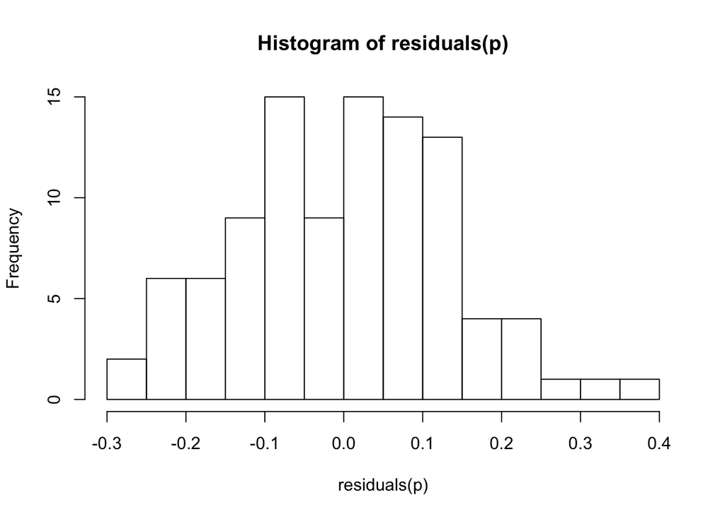

```r
#plot(p$residuals, x)
hist(residuals(p), breaks=14)
```

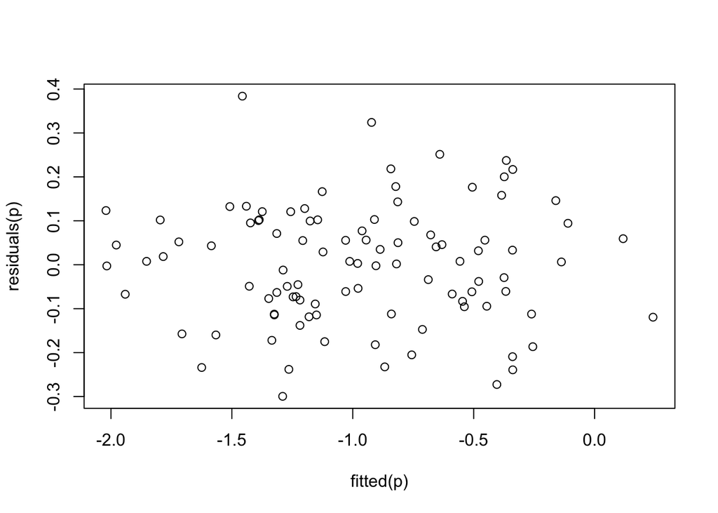

```r
plot(fitted(p),residuals(p))
```

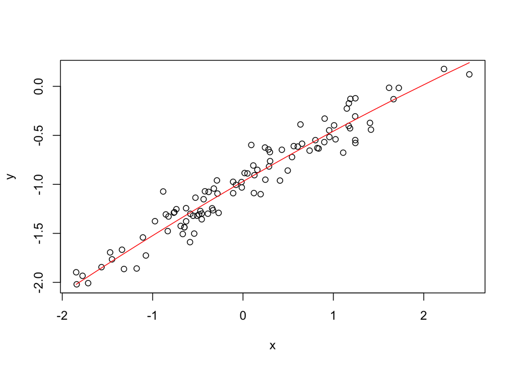

```r
plot(x, y)
y_pred <- predict(p, data.frame(x, x2))
lines(sort(x), y_pred[order(x)], col = "red")
```

As with the noisier data set previously shown, the p value for the x^2 term does not meet the standard 0.05 threshold. In this case, the coeffiecient for the x^2 term is closer to 0 than before.

A visual comparison of the fit line and histogram appears that the linear and polynomial are still very similar.

## 3. Logistic regression, calibration and discrimination

An extensive data set was used to develop a prognostic model for 6-month unfavorable outcome (d.unfav) after moderate and severe TBI (d.gos = 3, 4). The strongest predictors were age, motor score and pupil reactivity. See “TBI Background Document.pdf” (in Canvas under Files -> Data) for the data dictionary. Note: Truncated systolic blood pressure (d.sysbt) is also included in the dataset but does not appear on the list in the document. The data are from Steyerberg and are in SPSS format. The dataset can be found in Canvas under Files -> Data -> TBI.sav.

### (a) Using the rms package in R, fit a logistic regression model (binary outcome) with these 3 variables (age, d.motor and pupil.i) in the US data set (trial=75). First create 5 dummy variables for motor score and 2 for pupil reactivity. Be sure to investigate a potential nonlinear effect of age in the model.

```r
wd <- getwd()
setwd("..")
parent <- getwd()

tbi = read.spss(file = paste(parent,'TBI.sav', sep='/'), to.data.frame = TRUE)
```

```
## re-encoding from CP1252
```

```r
print(paste(parent,'TBI.sav', sep='/'))
```

```
## [1] "/Users/seth/OneDrive - The University of Colorado Denver/Documents/BIOS_6645/TBI.sav"
```

```r
setwd(wd)

# filter dataset
tbi = tbi[tbi$trial == 'Tirilazad US', ]

# convert d.motor column to factor
tbi$d.motor = as.factor(tbi$d.motor)
```

LRM model using built in factor method to create dummy variables

```r
tbi_model = lrm(d.unfav ~ age + d.motor + pupil.i, data=tbi, x=TRUE, y=TRUE)
tbi_model
```

```
## Logistic Regression Model
##
##  lrm(formula = d.unfav ~ age + d.motor + pupil.i, data = tbi,
##      x = TRUE, y = TRUE)
##
##                        Model Likelihood     Discrimination    Rank Discrim.
##                           Ratio Test           Indexes           Indexes
##  Obs          1041    LR chi2     262.94    R2       0.304    C       0.784
##   0            646    d.f.             8    g        1.346    Dxy     0.567
##   1            395    Pr(> chi2) <0.0001    gr       3.841    gamma   0.569
##  max |deriv| 2e-11                          gp       0.266    tau-a   0.267
##                                             Brier    0.179
##
##                             Coef    S.E.   Wald Z Pr(>|Z|)
##  Intercept                  -1.5203 0.7755 -1.96  0.0499
##  age                         0.0442 0.0060  7.33  <0.0001
##  d.motor=2                   0.4352 0.7625  0.57  0.5682
##  d.motor=3                   0.0698 0.7608  0.09  0.9269
##  d.motor=4                  -0.7078 0.7479 -0.95  0.3440
##  d.motor=5                  -1.4894 0.7498 -1.99  0.0470
##  d.motor=6                  -1.9808 0.8507 -2.33  0.0199
##  pupil.i=one reactive        0.3042 0.2232  1.36  0.1729
##  pupil.i=no reactive pupils  1.2298 0.1921  6.40  <0.0001
##
```

```r
dd <- datadist(tbi)
options(datadist="dd")
summary(tbi_model)
```

```
##              Effects              Response : d.unfav
##
##  Factor                                     Low High Diff. Effect
##  age                                        23  41   18     0.79546
##   Odds Ratio                                23  41   18     2.21550
##  d.motor - 1:5                               5   1   NA     1.48940
##   Odds Ratio                                 5   1   NA     4.43430
##  d.motor - 2:5                               5   2   NA     1.92460
##   Odds Ratio                                 5   2   NA     6.85210
##  d.motor - 3:5                               5   3   NA     1.55910
##   Odds Ratio                                 5   3   NA     4.75470
##  d.motor - 4:5                               5   4   NA     0.78155
##   Odds Ratio                                 5   4   NA     2.18490
##  d.motor - 6:5                               5   6   NA    -0.49142
##   Odds Ratio                                 5   6   NA     0.61175
##  pupil.i - one reactive:both reactive        1   2   NA     0.30416
##   Odds Ratio                                 1   2   NA     1.35550
##  pupil.i - no reactive pupils:both reactive  1   3   NA     1.22980
##   Odds Ratio                                 1   3   NA     3.42050
##  S.E.    Lower 0.95 Upper 0.95
##  0.10859  0.582620   1.00830
##       NA  1.790700   2.74090
##  0.74983  0.019721   2.95900
##       NA  1.019900  19.27900
##  0.24740  1.439700   2.40950
##       NA  4.219300  11.12800
##  0.23633  1.095900   2.02230
##       NA  2.992000   7.55600
##  0.18096  0.426870   1.13620
##       NA  1.532400   3.11500
##  0.43750 -1.348900   0.36605
##       NA  0.259530   1.44200
##  0.22316 -0.133220   0.74154
##       NA  0.875270   2.09920
##  0.19205  0.853370   1.60620
##       NA  2.347500   4.98380
```

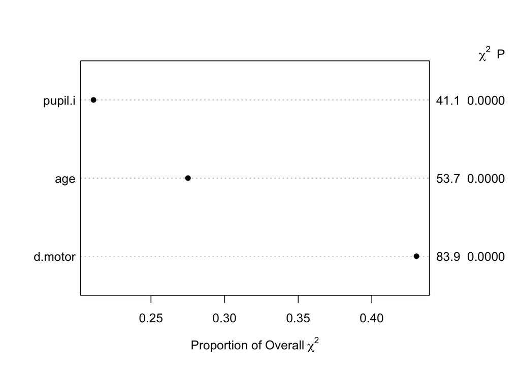

```r
plot(anova(tbi_model), what='proportion chisq') # relative importance
```

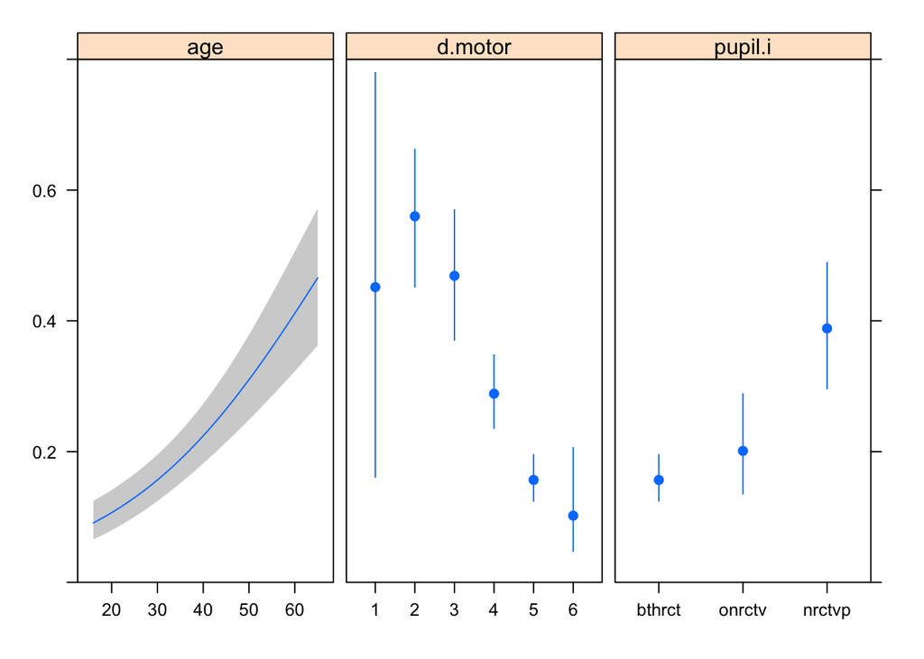

```r
plot(Predict(tbi_model, fun=plogis)) # predicted values
```

```r
rms::validate(tbi_model, method="boot", B=500) # bootstrapped validation
```

```
##           index.orig training    test optimism index.corrected   n
## Dxy           0.5672   0.5729  0.5604   0.0125          0.5547 500
## R2            0.3037   0.3122  0.2943   0.0179          0.2858 500
## Intercept     0.0000   0.0000 -0.0165   0.0165         -0.0165 500
## Slope         1.0000   1.0000  0.9577   0.0423          0.9577 500
## Emax          0.0000   0.0000  0.0123   0.0123          0.0123 500
## D             0.2516   0.2599  0.2428   0.0172          0.2345 500
## U            -0.0019  -0.0019  0.0006  -0.0025          0.0006 500
## Q             0.2535   0.2618  0.2422   0.0197          0.2339 500
## B             0.1792   0.1774  0.1810  -0.0036          0.1828 500
## g             1.3459   1.3827  1.3201   0.0625          1.2833 500
## gp            0.2663   0.2692  0.2613   0.0079          0.2584 500
```

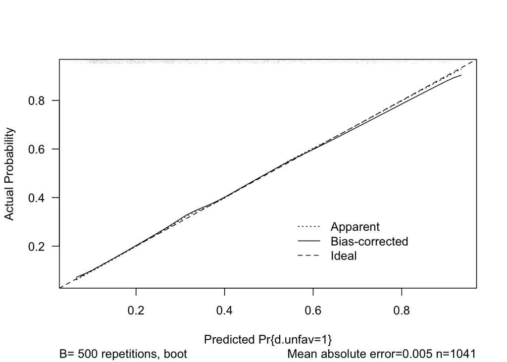

```
##
## n=1041   Mean absolute error=0.005   Mean squared error=6e-05
## 0.9 Quantile of absolute error=0.013
```

```r
my.calib <- rms::calibrate(tbi_model, method="boot", B=500) # model calibration
plot(my.calib, las=1)
```

```r
#
# penalty <- pentrace(mod1, penalty=c(0.5,1,2,3,4,6,8,12,16,24), maxit=25)
# mod1_pen <- update(mod1, penalty=penalty$penalty)
# effective.df(mod1_pen)
# mod1_pen
```

Alternative method with dummy encoding instead of factors

```r
# can use dummies package to create dummy encoded variables
#install.packages('dummies')
library(dummies)
d_tbi = dummy.data.frame(tbi, names = c("d.motor","pupil.i") , sep = "_")

# or model.matrix to create dummy encoded variables
#model.matrix(~tbi$d.motor)

d_model = lrm(d.unfav ~ age + d.motor_1 + d.motor_2 + d.motor_3 + d.motor_4 + d.motor_6 + `pupil.i_no reactive pupils` + `pupil.i_one reactive`, data=d_tbi, x=TRUE, y=TRUE)
d_model
```

```
## Logistic Regression Model
##
##  lrm(formula = d.unfav ~ age + d.motor_1 + d.motor_2 + d.motor_3 +
##      d.motor_4 + d.motor_6 + `pupil.i_no reactive pupils` + `pupil.i_one reactive`,
##      data = d_tbi, x = TRUE, y = TRUE)
##
##                        Model Likelihood     Discrimination    Rank Discrim.
##                           Ratio Test           Indexes           Indexes
##  Obs          1041    LR chi2     262.94    R2       0.304    C       0.784
##   0            646    d.f.             8    g        1.346    Dxy     0.567
##   1            395    Pr(> chi2) <0.0001    gr       3.841    gamma   0.569
##  max |deriv| 1e-11                          gp       0.266    tau-a   0.267
##                                             Brier    0.179
##
##                             Coef    S.E.   Wald Z Pr(>|Z|)
##  Intercept                  -3.0097 0.2549 -11.81 <0.0001
##  age                         0.0442 0.0060   7.33 <0.0001
##  d.motor_1                   1.4894 0.7498   1.99 0.0470
##  d.motor_2                   1.9246 0.2474   7.78 <0.0001
##  d.motor_3                   1.5591 0.2363   6.60 <0.0001
##  d.motor_4                   0.7815 0.1810   4.32 <0.0001
##  d.motor_6                  -0.4914 0.4375  -1.12 0.2613
##  pupil.i_no reactive pupils  1.2298 0.1921   6.40 <0.0001
##  pupil.i_one reactive        0.3042 0.2232   1.36 0.1729
##
```

```r
dd <- datadist(d_tbi)
options(datadist="dd")
summary(d_model)
```

```
##              Effects              Response : d.unfav
##
##  Factor                     Low High Diff. Effect   S.E.    Lower 0.95
##  age                        23  41   18     0.79546 0.10859  0.582620
##   Odds Ratio                23  41   18     2.21550      NA  1.790700
##  d.motor_1                   0   1    1     1.48940 0.74983  0.019721
##   Odds Ratio                 0   1    1     4.43430      NA  1.019900
##  d.motor_2                   0   1    1     1.92460 0.24740  1.439700
##   Odds Ratio                 0   1    1     6.85210      NA  4.219300
##  d.motor_3                   0   1    1     1.55910 0.23633  1.095900
##   Odds Ratio                 0   1    1     4.75470      NA  2.992000
##  d.motor_4                   0   1    1     0.78155 0.18096  0.426870
##   Odds Ratio                 0   1    1     2.18490      NA  1.532400
##  d.motor_6                   0   1    1    -0.49142 0.43750 -1.348900
##   Odds Ratio                 0   1    1     0.61175      NA  0.259530
##  pupil.i_no reactive pupils  0   1    1     1.22980 0.19205  0.853370
##   Odds Ratio                 0   1    1     3.42050      NA  2.347500
##  pupil.i_one reactive        0   1    1     0.30416 0.22316 -0.133220
##   Odds Ratio                 0   1    1     1.35550      NA  0.875270
##  Upper 0.95
##   1.00830
##   2.74090
##   2.95900
##  19.27900
##   2.40950
##  11.12800
##   2.02230
##   7.55600
##   1.13620
##   3.11500
##   0.36605
##   1.44200
##   1.60620
##   4.98380
##   0.74154
##   2.09920
```

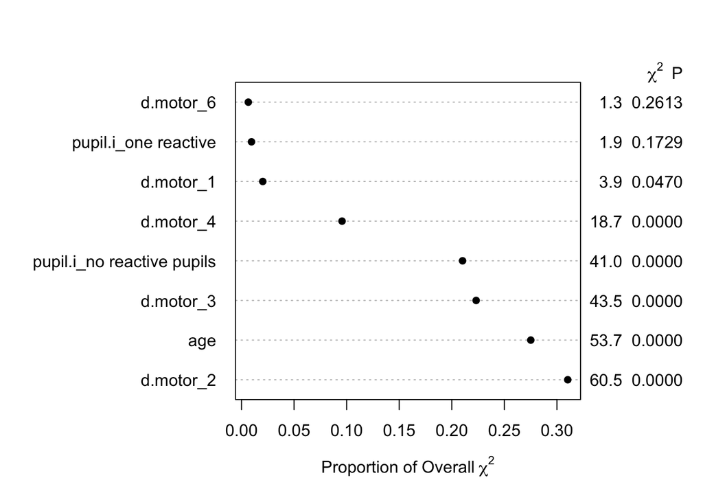

```r
plot(anova(d_model), what='proportion chisq') # relative importance
```

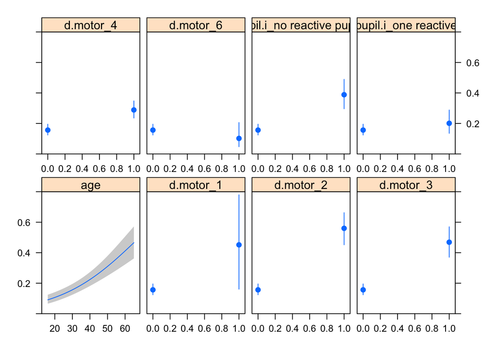

```r
plot(Predict(d_model, fun=plogis)) # predicted values
```

```r
rms::validate(d_model, method="boot", B=500) # bootstrapped validation
```

```
##           index.orig training    test optimism index.corrected   n
## Dxy           0.5672   0.5752  0.5603   0.0149          0.5523 500
## R2            0.3037   0.3140  0.2943   0.0197          0.2840 500
## Intercept     0.0000   0.0000 -0.0212   0.0212         -0.0212 500
## Slope         1.0000   1.0000  0.9547   0.0453          0.9547 500
## Emax          0.0000   0.0000  0.0138   0.0138          0.0138 500
## D             0.2516   0.2617  0.2428   0.0189          0.2327 500
## U            -0.0019  -0.0019  0.0006  -0.0026          0.0006 500
## Q             0.2535   0.2636  0.2422   0.0215          0.2321 500
## B             0.1792   0.1771  0.1810  -0.0039          0.1832 500
## g             1.3459   1.3882  1.3198   0.0684          1.2774 500
## gp            0.2663   0.2701  0.2614   0.0087          0.2576 500
```

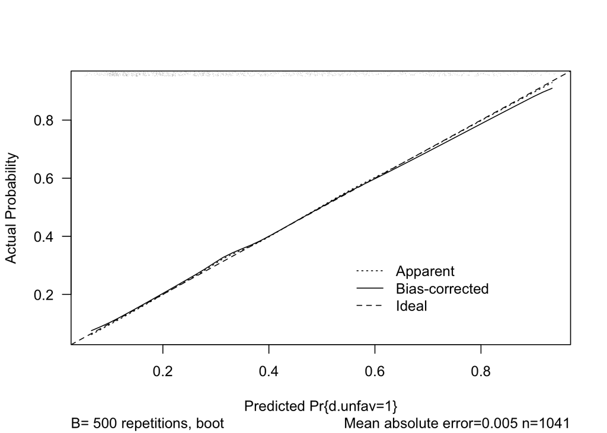

```
##
## n=1041   Mean absolute error=0.005   Mean squared error=5e-05
## 0.9 Quantile of absolute error=0.013
```

```r
my.calib <- rms::calibrate(d_model, method="boot", B=500) # model calibration
plot(my.calib, las=1)
```